# Dipole Moments and Ionic Bonding

Chem 3240 · Lecture 8.6

Davit Potoyan

## The Electric Dipole Moment

- A dipole measures the **asymmetry** of a charge distribution.

$$\vec{\mu} = \sum_{i=1}^{N} Q_i\,\vec{r_i}$$

- A **vector** pointing from negative to positive charge.
- SI units of **C m**; often quoted in **debye** (D).

## Dipole as an Expectation Value

- For a molecule, take the **expectation value** of the dipole operator.

$$\hat{\mu}_x = \sum_{i=1}^{N} Q_i x_i, \quad \hat{\mu}_y = \sum_{i=1}^{N} Q_i y_i, \quad \hat{\mu}_z = \sum_{i=1}^{N} Q_i z_i$$

$$\left\langle \vec{\hat{\mu}} \right\rangle = \int \psi^* \, \vec{\hat{\mu}} \, \psi \, d\tau$$

## Ionic versus Covalent

- **Similar** electronegativity: orbitals spread evenly, a **covalent** bond.
- **Different** electronegativity: orbitals lopsided, **ionic** character and a permanent dipole.
- Neither **pure ionic** nor **pure covalent** bonds truly exist.

## When Is a Bond Ionic? (LiF)

- Compare the cost of **electron transfer**.
- Li ionization energy $\approx 5.4$ eV, F electron affinity $\approx 3.5$ eV.
- Difference of only **1.9 eV**, so ionic bonding is favorable.
- Contrast the **C-H** bond: the gap exceeds **10 eV**, so it stays covalent.

## The Ionic Binding Curve

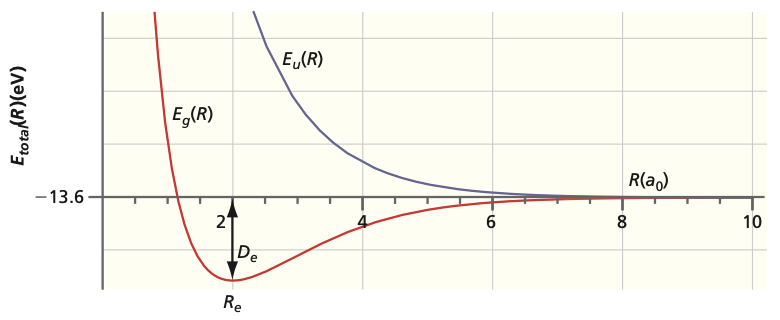

- **Coulomb attraction** at long range pulls the ions together.

$$E(R) = \frac{Q_1 Q_2}{4\pi\epsilon_0 R} + b\,e^{-aR}$$

- Short-range **Pauli repulsion** sets the minimum at $R_e$.

## Why the Short-Range Repulsion?

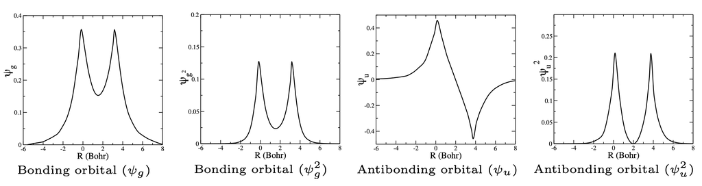

- Close in, filled orbitals **overlap**.
- Both **bonding and antibonding** orbitals fill.
- Antibonding repulsion **outweighs** bonding attraction.
- This is the **Pauli repulsion** term $b\,e^{-aR}$.

## Dissociation Goes to Atoms

- An **avoided crossing** switches ionic to covalent on the way out.
- The molecule breaks into **neutral atoms**, not ions.

## Intermolecular Forces

- Even with **no chemical bond**, molecules attract weakly.
- Three weak attractions, **all** scaling as $1/R^6$:
  - **Dipole-dipole** (Keesom)
  - **Dipole-induced-dipole**
  - **Dispersion** (London)
- Balanced by **Pauli repulsion** at short range.

## The Three $1/R^6$ Attractions

- **Dipole-dipole**, thermally averaged:
  $$\langle V \rangle_{dd} = -\frac{2}{3kT}\left(\frac{\mu_A \mu_B}{4\pi\epsilon_0}\right)^2 \frac{1}{R^6}$$
- **Dispersion** needs no permanent dipole:
  $$\langle V \rangle_{disp} = -\frac{3}{2}\left(\frac{E_A E_B}{E_A + E_B}\right)\frac{\alpha_A \alpha_B}{(4\pi\epsilon_0)^2}\frac{1}{R^6}$$

## The Lennard-Jones Potential

- Combine $1/R^6$ attraction with a steep repulsion.

$$V(R) = 4\epsilon\left[\left(\frac{\sigma}{R}\right)^{12} - \left(\frac{\sigma}{R}\right)^{6}\right]$$

- $R^{-12}$ is **Pauli repulsion**, $R^{-6}$ is **van der Waals** binding.
- Well depth $\epsilon$ sits at $R_e = 2^{1/6}\sigma$.

# Takeaway

> A **dipole** is the expectation value of $\sum_i Q_i \vec{r_i}$; an **ionic bond** is Coulomb attraction $Q_1 Q_2/4\pi\epsilon_0 R$ tamed by **Pauli repulsion**, and weak $1/R^6$ forces plus that repulsion give the **Lennard-Jones** potential $4\epsilon[(\sigma/R)^{12} - (\sigma/R)^{6}]$.